# CEO-REQUEST CHALLENGE

# Michael Hayman

# 23 October 2020

## Introduction

### Question:

Should Olist remove underperforming sellers from its marketplace?

### Answer:

Yes, under certain conditions, and dependent on expert knowledge.

### Approach

- Examines Olist database, to determine which factors may isolate sales and factors reducing profitability.
- Greatest opportunities lie in list of sellers, with very different circumstances.
- Incoporating consequences of star ratings, highlight least profitable sellers.
- Consider the potential reduced IT costs, due to reduced order numbers.

## Underperforming sellers

Which sellers are underperforming in the Olist marketplace?

### Underperforming sellers: Context

We can make a face value calculation of revenue per seller, as follows:

- Revenue per seller is share (10%) of total cost of orders from them.
- There's a cost per seller associated with each bad review, estimated here as follows:

| Stars for bad review | Cost to Olist (BRL) |
| --- | --- |
| 3 | 40 |
| 2 | 50 |
| 1 | 100 |

Noting that the relationship is complex and dynamic, and there are other factors impacting profitability (e.g. IT costs, which are address in the next section).

```python
sellers.head()
```

|  | seller_id | seller_city | seller_state | delay_to_carrier | wait_time | date_first_sale | date_last_sale | active_months_on_olist | share_one_stars | share_of_five_stars | review_score | cost_of_reviews | n_orders | quantity | quantity_per_order | sales | revenue_from_sales | revenue_from_monthly_fee | profit |
| --- | --- | --- | --- | --- | --- | --- | --- | --- | --- | --- | --- | --- | --- | --- | --- | --- | --- | --- | --- |
| 0 | 3442f8959a84dea7ee197c632cb2df15 | campinas | SP | 0.000000 | 13.018588 | 2017-05-05 16:25:11 | 2017-08-30 12:50:19 | 4 | 0.333333 | 0.333333 | 3.00 | 140 | 3 | 3 | 1.000 | 218.70 | 21.870 | 320 | 201.870 |
| 1 | d1b65fc7debc3361ea86b5f14c68d2e2 | mogi guacu | SP | 0.000000 | 9.065716 | 2017-03-29 02:10:34 | 2018-06-06 20:15:21 | 15 | 0.050000 | 0.725000 | 4.55 | 240 | 40 | 41 | 1.025 | 11703.07 | 1170.307 | 1200 | 2130.307 |
| 2 | ce3ad9de960102d0677a81f5d0bb7b2d | rio de janeiro | RJ | 0.000000 | 4.042292 | 2018-07-30 12:44:49 | 2018-07-30 12:44:49 | 1 | 0.000000 | 1.000000 | 5.00 | 0 | 1 | 1 | 1.000 | 158.00 | 15.800 | 80 | 95.800 |
| 3 | c0f3eea2e14555b6faeea3dd58c1b1c3 | sao paulo | SP | 0.000000 | 5.667187 | 2018-08-03 00:44:08 | 2018-08-03 00:44:08 | 1 | 0.000000 | 1.000000 | 5.00 | 0 | 1 | 1 | 1.000 | 79.99 | 7.999 | 80 | 87.999 |
| 4 | 51a04a8a6bdcb23deccc82b0b80742cf | braganca paulista | SP | 3.353727 | 35.314861 | 2017-11-14 12:15:25 | 2017-11-14 12:15:25 | 1 | 1.000000 | 0.000000 | 1.00 | 100 | 1 | 1 | 1.000 | 167.99 | 16.799 | 80 | -3.201 |

```python
sorted_sellers = sellers.sort_values('profit').reset_index(drop=True)
```

```python
split_sellers = sellers[sellers['profit'] > 0]
sorted_split_sellers = split_sellers.sort_values('profit').reset_index(drop=True)
```

### Underperforming sellers: Visual representation

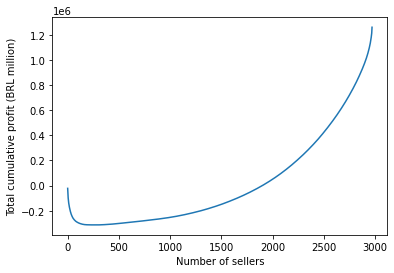

```python
plt.plot(np.cumsum(sorted_sellers.profit))
plt.xlabel('Number of sellers')
plt.ylabel('Total cumulative profit (BRL million)')
```

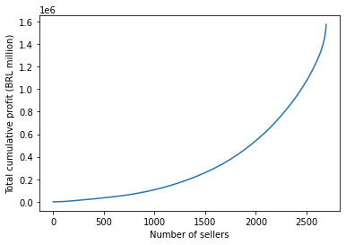

```python
plt.plot(np.cumsum(sorted_split_sellers.profit))
plt.xlabel('Number of sellers')
plt.ylabel('Total cumulative profit (BRL million)')
```

```python
old_order_num = sorted_sellers.n_orders.sum()
old_order_num
```

```
99844
```

```python
new_order_num = sorted_split_sellers.n_orders.sum()
new_order_num
```

```
60027
```

```python
change_order_num = new_order_num - old_order_num
change_order_num
```

```
-39817
```

```python
change_order_perc = change_order_num / old_order_num
round(change_order_perc,3)
```

```
-0.399
```

```python
old_profit = sorted_sellers.profit.sum()
round(old_profit,2)
```

```
1259445.22
```

```python
new_profit = sorted_split_sellers.profit.sum()
round(new_profit,2)
```

```
1572721.73
```

```python
change_profit = new_profit - old_profit
round(change_profit,2)
```

```
313276.5
```

```python
change_profit_perc = change_profit / old_profit
round(change_profit_perc,3)
```

```
0.249
```

### Underperforming sellers: Other considerations

I recommend ending sales from those sellers that are underperforming to the greatest extent, with this model taking the cost of negative reviews into account.

If customers are limited to ordering from sellers located close to them, this may reduce delivery times and bad reviews. This can be tested, to some extent, by modelling the distance of customer to seller against review scores, and/or delivery time versus expected delivery time.

## Scaling IT costs

Costs of Olist's IT infrastructure are related to total orders. These costs also affect profitability.

### Scaling IT costs: Context

Olist's IT costs increase with the total (i.e. global) amount of orders processed. However, economies of scale mean that the average cost per total orders decreases as total orders increase further.

This relationship is roughly estimated by a the following equation, to determine the constant A:

A = $\frac{Total IT costs}{\sqrt{orders}}$

Where ITcost is the total cost of IT to Olist, and Orders of is the value of total orders.

Since the total IT costs since the birth of the marketplace have amounted to 500,000 BRL, the relationship can be specified as follows:

```python
total_IT_costs = 500_000
n_orders = sellers.n_orders.sum()
A = total_IT_costs / (n_orders**0.5)
```

```python
new_total_IT_costs = A * (new_order_num ** 0.5)
round(new_total_IT_costs,2)
```

```
387687.98
```

```python
IT_savings = total_IT_costs - new_total_IT_costs
round(IT_savings,2)
```

```
112312.02
```

```python
IT_savings_perc = IT_savings / old_profit
round(IT_savings_perc,3)
```

```
0.089
```

```python
total_change_profit = change_profit + IT_savings
round(total_change_profit,2)
```

```
425588.52
```

```python
total_change_profit_perc = total_change_profit / old_profit
round(total_change_profit_perc,3)
```

```
0.338
```

### Scaling IT costs: Visual representation

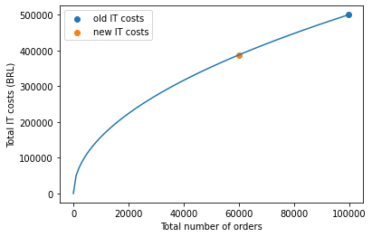

```python
number_orders_array = np.arange(0, old_order_num, 1000)
plt.plot(number_orders_array, (number_orders_array **0.5) * A)
plt.scatter(old_order_num, (old_order_num **0.5) * A, label = 'old IT costs')
plt.scatter(new_order_num, (new_order_num **0.5) * A, label = 'new IT costs')
plt.legend()
plt.xlabel('Total number of orders')
plt.ylabel('Total IT costs (BRL)')
```

### Scaling IT costs: Other considerations

While our modelling is useful, the relationship between orders and IT costs is probably more complex.

At different scales, the nature of this relationship is likely to change (e.g. shifting more of storage and computing power to cloud computing, and more cost effective enterprise-level computing).